# tp4_Bance_Stephane

Stéphane BANCE

# Partie A

## A1

```r
A = matrix(1:25, 5, 5)
B = matrix(1:25, 5, 5, byrow = TRUE)

print(paste0(all(B == t(A)), " : B est bien la transposée de A"))
```

```
## [1] "TRUE : B est bien la transposée de A"
```

```r
rownames(B) <- paste0("L", 1:5)
colnames(B) <- paste0("C", 1:5)
```

### a

```r
B[,3]
```

```
## L1 L2 L3 L4 L5
##  3  8 13 18 23
```

### b

```r
B[c(1,5),]
```

```
##    C1 C2 C3 C4 C5
## L1  1  2  3  4  5
## L5 21 22 23 24 25
```

### c

```r
B[,"C1",drop=FALSE]
```

```
##    C1
## L1  1
## L2  6
## L3 11
## L4 16
## L5 21
```

## A2

```r
set.seed(4)
X <- matrix(
  rnorm(n = 36, mean = 3, sd = sqrt(10)),
  nrow = 6,
  ncol = 6
)
```

### a

Il y a 24 valeurs supérieurs à 3.

### b

La valeur minimun est à la position 34 et la valeur maximun est à la position 9.

### c

```r
X01 <- ifelse(X > 3, 1, 0)
X01
```

```
##      [,1] [,2] [,3] [,4] [,5] [,6]
## [1,]    1    0    1    0    1    1
## [2,]    0    0    0    0    0    1
## [3,]    1    1    1    1    1    0
## [4,]    1    1    1    1    1    0
## [5,]    1    1    1    1    0    1
## [6,]    1    1    0    1    1    0
```

```r
dim(X01)
```

```
## [1] 6 6
```

## A3

### a

```r
rowSums(durer)
```

```
## [1] 34 34 34 34
```

```r
colSums(durer)
```

```
## [1] 34 34 34 34
```

```r
sum(diag(durer))
```

```
## [1] 34
```

```r
sum(diag(durer[, ncol(durer):1]))
```

```
## [1] 34
```

### b

```r
all(rowSums(durer) == sum(durer[,1])) & all(colSums(durer) == sum(durer[,1])) &
sum(diag(durer)) == sum(durer[,1]) & sum(diag(durer[, ncol(durer):1])) == sum(durer[,1])
```

```
## [1] TRUE
```

### c

```r
rowSums(candidat)
```

```
## [1] 15 15 16
```

```r
colSums(candidat)
```

```
## [1] 15 15 16
```

On voie que le problème est à la troisième ligne, troisième colonne. Qui est 1 point trop grand. donc on fait candidat[3, 3] <- candidat[3, 3] - 1.

```r
candidat[3, 3] <- candidat[3, 3] - 1
all(rowSums(candidat) == sum(candidat[,1])) & all(colSums(candidat) == sum(candidat[,1])) &
sum(diag(candidat)) == sum(candidat[,1]) & sum(diag(candidat[, ncol(candidat):1])) == sum(candidat[,1])
```

```
## [1] TRUE
```

## A4

```r
nombres <- 1:10

table_mult <- outer(nombres, nombres, "*")

print(table_mult)
```

```
##       [,1] [,2] [,3] [,4] [,5] [,6] [,7] [,8] [,9] [,10]
##  [1,]    1    2    3    4    5    6    7    8    9    10
##  [2,]    2    4    6    8   10   12   14   16   18    20
##  [3,]    3    6    9   12   15   18   21   24   27    30
##  [4,]    4    8   12   16   20   24   28   32   36    40
##  [5,]    5   10   15   20   25   30   35   40   45    50
##  [6,]    6   12   18   24   30   36   42   48   54    60
##  [7,]    7   14   21   28   35   42   49   56   63    70
##  [8,]    8   16   24   32   40   48   56   64   72    80
##  [9,]    9   18   27   36   45   54   63   72   81    90
## [10,]   10   20   30   40   50   60   70   80   90   100
```

### a

Il y a 42 éléments uniques.

### b

Il y a 75% de nombre pairs dans la table.

### c

```r
valeurs_dessus <- table_mult[upper.tri(table_mult)]

nb_valeurs <- length(valeurs_dessus)
```

Il y a 45 en dessus de la diagonale.

## A5

### a

```r
altitude_max <- max(volcano)

positions_max <- which(volcano == altitude_max, arr.ind = TRUE)
```

L’altitude max est 195 et se trouve à 20, 31.

### b

La proportion du terrain en-dessus de 150m est 23.13925%.

### c

```r
moyennes_lignes <- rowMeans(volcano)
ligne_plus_haute <- which.max(moyennes_lignes)
```

C’est la ligne 22.

### d

```r
deniveles <- apply(volcano, 2, max) - apply(volcano, 2, min);
colonne_plus_forte <- which.max(deniveles)
```

C’est la colonne 31.

### e

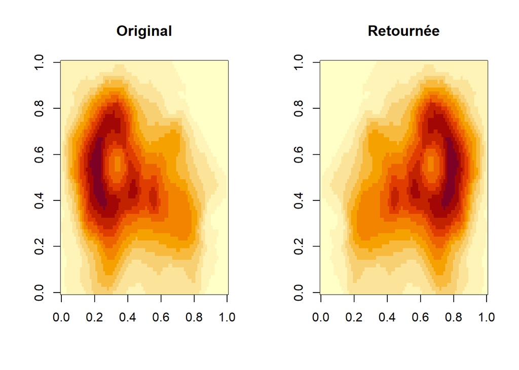

```r
volcano_retourne <- volcano[nrow(volcano):1, ]
par(mfrow = c(1, 2))


image(volcano, main = "Original")
image(volcano_retourne, main = "Retournée")
```

# Partie B

## B1

### a

```r
chiffre_affaire_par_magasin <- Q %*% prix
chiffre_affaire_par_magasin
```

```
##         [,1]
## Lyon    9990
## Lille   9830
## Nantes 12385
```

### b

```r
marge_par_magasin <- chiffre_affaire_par_magasin - Q %*% cout
marge_par_magasin
```

```
##        [,1]
## Lyon   4230
## Lille  4250
## Nantes 5140
```

### c

```r
matrice_ca <- Q %*% diag(prix)
position_max <- which(matrice_ca == max(matrice_ca), arr.ind = TRUE)

nom_magasin <- rownames(Q)[position_max[1, "row"]]
nom_produit <- colnames(Q)[position_max[1, "col"]]
```

C’est la combinaison Nantesx raquette

### d

```r
all(rowSums(matrice_ca) == chiffre_affaire_par_magasin)
```

```
## [1] TRUE
```

## B2

### a

```r
quantites_aliments <- solve(M, stock)

quantites_aliments
```

```
## [1] 70 40 70 60
```

Pour utiliser exactement tout le stock disponible, il faut produire 70 tonnes de l’aliment 1, 40 tonnes de l’aliment 2, 70 tonnes de l’aliment 3 et 60 tonnes de l’aliment 4.

### b

```r
all.equal(as.vector(M %*% quantites_aliments), stock)
```

```
## [1] TRUE
```

### c

```r
M2 <- M
M2[4, ] <- M[1, ] + M[2, ]
M2
```

```
##      [,1] [,2] [,3] [,4]
## [1,]  0.4  0.2  0.1  0.3
## [2,]  0.2  0.4  0.2  0.1
## [3,]  0.3  0.2  0.5  0.2
## [4,]  0.6  0.6  0.3  0.4
```

```r
det_M <- det(M2)
det_M
```

```
## [1] 0
```

Le déterminant vaut 0, soit il y’a aucune solution soit une infite. donc solve() va lever une exception.

## B2

### a

```r
rowSums(P)
```

```
## A B C
## 1 1 1
```

### b

```r
parts1 <- parts0 %*% P
parts2 <- parts1 %*% P
parts3 <- parts2 %*% P
parts1
```

```
##         A     B     C
## [1,] 0.49 0.315 0.195
```

```r
parts2
```

```
##            A       B      C
## [1,] 0.48325 0.32425 0.1925
```

```r
parts3
```

```
##            A         B         C
## [1,] 0.47865 0.3300125 0.1913375
```

### c

```r
P2 <- P %*% P
P4 <- P2 %*% P2
P8 <- P4 %*% P4
P12 <- P8 %*% P4
parts12 <- parts0 %*% P12
parts12
```

```
##             A         B         C
## [1,] 0.468572 0.3401093 0.1913187
```

### d

```r
P16 <- P8 %*% P8
P32 <- P16 %*% P16
P64 <- P32 %*% P32
P64
```

```
##           A         B         C
## A 0.4680851 0.3404255 0.1914894
## B 0.4680851 0.3404255 0.1914894
## C 0.4680851 0.3404255 0.1914894
```

En calculant P64 de la même façon, on remarque que toutes les lignes de cette matrice sont identiques (ou presque, aux erreurs d’arrondi près). Chaque ligne vaut environ 46.81 % pour A, 34.04 % pour B et 19.15 % pour C. Cela signifie qu’après un très grand nombre de mois, la probabilité de se retrouver chez un opérateur donné ne dépend plus du tout de l’opérateur de départ.

### e

```r
decomp <- eigen(t(P))
pos_pi <- which(round(decomp$values, 10) == 1)
vecteur_pi <- decomp$vectors[, pos_pi]
pi_stationnaire <- vecteur_pi / sum(vecteur_pi)
names(pi_stationnaire) <- c("A", "B", "C")
```

# Partie C

## C1

```r
total <- sum(Titanic)
par_classe <- apply(Titanic, "Class", sum)
part_equipage <- 100 * par_classe["Crew"] / total

par_classe
```

```
##  1st  2nd  3rd Crew
##  325  285  706  885
```

Il y avait 2201 personnes à bord : 325 en 1re classe, 285 en 2e classe, 706 en 3e classe et 885 membres d’équipage. L’équipage représentait donc 40.2 % des personnes à bord.

## C2

```r
taux_global <- 100 * sum(Titanic[, , , "Yes"]) / sum(Titanic)

tab_classe <- apply(Titanic, c("Class", "Survived"), sum)
taux_classe <- 100 * prop.table(tab_classe, 1)[, "Yes"]

tab_sexe <- apply(Titanic, c("Sex", "Survived"), sum)
taux_sexe <- 100 * prop.table(tab_sexe, 1)[, "Yes"]

round(taux_classe, 1)
```

```
##  1st  2nd  3rd Crew
## 62.5 41.4 25.2 24.0
```

```r
round(taux_sexe, 1)
```

```
##   Male Female
##   21.2   73.2
```

Le taux de survie global est de 32.3 %. Par classe, il est de 62.5 % en 1re classe, 41.4 % en 2e, 25.2 % en 3e et 24 % pour l’équipage. Par sexe, il est de 73.2 % pour les femmes contre 21.2 % pour les hommes.

## C3

```r
sexe_age <- apply(Titanic, c("Sex", "Age", "Survived"), sum)
taux_sexe_age <- 100 * sexe_age[, , "Yes"] / (sexe_age[, , "Yes"] + sexe_age[, , "No"])

round(taux_sexe_age, 1)
```

```
##         Age
## Sex      Child Adult
##   Male    45.3  20.3
##   Female  62.2  74.4
```

Les taux de survie sont de 62.2 % pour les filles, 45.3 % pour les garçons, 74.4 % pour les femmes adultes et 20.3 % pour les hommes adultes. La règle a été appliquée en grande partie : les femmes (adultes ou enfants) et les enfants s’en sortent bien mieux que les hommes adultes.

## c4

```r
classe_sexe <- apply(Titanic, c("Class", "Sex", "Survived"), sum)
taux_classe_sexe <- 100 * classe_sexe[, , "Yes"] / (classe_sexe[, , "Yes"] + classe_sexe[, , "No"])

round(taux_classe_sexe, 1)
```

```
##       Sex
## Class  Male Female
##   1st  34.4   97.2
##   2nd  14.0   87.7
##   3rd  17.3   45.9
##   Crew 22.3   87.0
```

Les femmes de 3e classe ont un taux de survie de 45.9 %, contre 34.4 % pour les hommes de 1re classe. Les deux valeurs sont proches : le sexe et la classe ont tous deux joué un rôle important. Être une femme apportait un avantage considérable à classe égale, mais l’appartenance à la 1re classe compensait presque entièrement le fait d’être un homme face à une femme de 3e classe.

## c5

```r
enfants <- apply(Titanic[, , "Child", ], c("Class", "Survived"), sum)
enfants_total <- rowSums(enfants)
enfants_survivants <- enfants[, "Yes"]

cbind(Total = enfants_total, Survivants = enfants_survivants)
```

```
##      Total Survivants
## 1st      6          6
## 2nd     24         24
## 3rd     79         27
## Crew     0          0
```

```r
tous_survecu <- all(enfants[c("1st", "2nd"), "No"] == 0)
```

Il y avait 6 enfants en 1re classe, 24 en 2e, 79 en 3e et 0 dans l’équipage. Les survivants sont au nombre de 6, 24, 27 et 0 respectivement. Oui, tous les enfants de 1re et 2e classe ont survécu, alors que 52 enfants de 3e classe sur 79 sont morts.

## C6

```r
df_titanic <- as.data.frame(Titanic)
head(df_titanic)
```

```
##   Class    Sex   Age Survived Freq
## 1   1st   Male Child       No    0
## 2   2nd   Male Child       No    0
## 3   3rd   Male Child       No   35
## 4  Crew   Male Child       No    0
## 5   1st Female Child       No    0
## 6   2nd Female Child       No    0
```

```r
xt <- xtabs(Freq ~ Class + Survived, data = df_titanic)
taux_classe_df <- 100 * prop.table(xt, 1)[, "Yes"]
round(taux_classe_df, 1)
```

```
##  1st  2nd  3rd Crew
## 62.5 41.4 25.2 24.0
```

```r
all.equal(taux_classe_df, taux_classe)
```

```
## [1] TRUE
```

On obtient 32 lignes, car `as.data.frame()` crée une ligne par combinaison de modalités des quatre variables (4 classes × 2 sexes × 2 âges × 2 issues), la colonne `Freq` contenant l’effectif de chaque combinaison. Les taux de survie par classe retrouvés avec `xtabs()` sont identiques à ceux de la question C2.

# Partie D

## D1

Prédictions, écrites avant d’exécuter :

- `l[1]` : de classe `list`, une liste de longueur 1 qui contient l’élément `a` (les entiers 1, 2, 3).
- `l[[1]]` : de classe `integer`, le vecteur `1 2 3`.
- `l$c$e` : de classe `numeric`, la valeur `2.5`.
- `l[["c"]]["d"]` : de classe `list`, une liste de longueur 1 qui contient l’élément `d` (la valeur `TRUE`).
- `length(l)` : de classe `integer`, la valeur `3`.
- `unlist(l)` : de classe `character`, un vecteur nommé de 6 éléments (`a1`, `a2`, `a3`, `b`, `c.d`, `c.e`) de valeurs `"1"`, `"2"`, `"3"`, `"x"`, `"TRUE"`, `"2.5"`.

```r
l <- list(a = 1:3, b = "x", c = list(d = TRUE, e = 2.5))

l[1]
```

```
## $a
## [1] 1 2 3
```

```r
class(l[1])
```

```
## [1] "list"
```

```r
l[[1]]
```

```
## [1] 1 2 3
```

```r
class(l[[1]])
```

```
## [1] "integer"
```

```r
l$c$e
```

```
## [1] 2.5
```

```r
class(l$c$e)
```

```
## [1] "numeric"
```

```r
l[["c"]]["d"]
```

```
## $d
## [1] TRUE
```

```r
class(l[["c"]]["d"])
```

```
## [1] "list"
```

```r
length(l)
```

```
## [1] 3
```

```r
class(length(l))
```

```
## [1] "integer"
```

```r
unlist(l)
```

```
##     a1     a2     a3      b    c.d    c.e
##    "1"    "2"    "3"    "x" "TRUE"  "2.5"
```

```r
class(unlist(l))
```

```
## [1] "character"
```

Les résultats correspondent aux prédictions. La différence vient de l’opérateur : `[` renvoie toujours une liste (une sous-liste), alors que `[[` et `$` extraient directement l’élément, ici le vecteur `1 2 3`. Dans `l[["c"]]["d"]`, `[[` extrait la sous-liste `c`, puis `[` en garde seulement `d`, ce qui donne une liste. Enfin, `unlist()` aplatit la liste en un seul vecteur : comme il mélange des entiers, du texte, un booléen et un décimal, tout est converti en `character`.

## D2

```r
fiche <- list(
  identite = list(nom = "Martin", prenom = "Léa", annee_naissance = 2003),
  notes = c(R = 15, stat = 12, eco = 13.5, anglais = 14),
  absences = 2L,
  commentaires = c("Étudiante sérieuse et régulière.",
                   "Doit consolider ses bases en économie.")
)
```

### a

Le prénom de deux façons :

```r
fiche$identite$prenom
```

```
## [1] "Léa"
```

```r
fiche[["identite"]][["prenom"]]
```

```
## [1] "Léa"
```

### b

La moyenne des notes :

```r
mean(fiche$notes)
```

```
## [1] 13.625
```

### c

Ajout de l’âge :

```r
fiche$age <- 2026 - fiche$identite$annee_naissance
fiche$age
```

```
## [1] 23
```

### d

Suppression des commentaires :

```r
fiche$commentaires <- NULL
str(fiche)
```

```
## List of 4
##  $ identite:List of 3
##   ..$ nom            : chr "Martin"
##   ..$ prenom         : chr "Léa"
##   ..$ annee_naissance: num 2003
##  $ notes   : Named num [1:4] 15 12 13.5 14
##   ..- attr(*, "names")= chr [1:4] "R" "stat" "eco" "anglais"
##  $ absences: int 2
##  $ age     : num 23
```

## D3

```r
promo <- list(
  list(nom = "Awa", filiere = "info", notes = c(15, 13.5, 17)),
  list(nom = "Bruno", filiere = "stat", notes = c(9, 12)),
  list(nom = "Chen", filiere = "info", notes = c(17, 15, 16, 18)),
  list(nom = "Dina", filiere = "eco", notes = c(11.5, 9)),
  list(nom = "Elias", filiere = "stat", notes = c(12, 14, 10))
)
```

### a

```r
nb_etudiants <- length(promo)
nom_3 <- promo[[3]]$nom
```

La liste contient 5 étudiants et le 3e s’appelle Chen.

### b

```r
noms <- sapply(promo, "[[", "nom")
filieres <- sapply(promo, "[[", "filiere")
noms
```

```
## [1] "Awa"   "Bruno" "Chen"  "Dina"  "Elias"
```

```r
filieres
```

```
## [1] "info" "stat" "info" "eco"  "stat"
```

### c

```r
notes <- lapply(promo, "[[", "notes")
names(notes) <- noms
nb_notes <- lengths(notes)
notes
```

```
## $Awa
## [1] 15.0 13.5 17.0
##
## $Bruno
## [1]  9 12
##
## $Chen
## [1] 17 15 16 18
##
## $Dina
## [1] 11.5  9.0
##
## $Elias
## [1] 12 14 10
```

```r
nb_notes
```

```
##   Awa Bruno  Chen  Dina Elias
##     3     2     4     2     3
```

Chaque étudiant a entre 2 et 4 notes : Awa = 3, Bruno = 2, Chen = 4, Dina = 2, Elias = 3.

### d

```r
moyennes <- sapply(notes, mean)

bilan <- data.frame(
  nom = noms,
  filiere = filieres,
  nb_notes = unname(nb_notes),
  moyenne = unname(moyennes)
)
bilan <- bilan[order(bilan$moyenne, decreasing = TRUE), ]
rownames(bilan) <- NULL
bilan
```

```
##     nom filiere nb_notes  moyenne
## 1  Chen    info        4 16.50000
## 2   Awa    info        3 15.16667
## 3 Elias    stat        3 12.00000
## 4 Bruno    stat        2 10.50000
## 5  Dina     eco        2 10.25000
```

### e

On ne peut pas les ranger directement dans une matrice, car les étudiants n’ont pas tous le même nombre de notes (de 2 à 4) et une matrice impose que toutes les lignes aient la même longueur.

## D4

```r
phrases <- c("R est un langage pour la statistique",
             "les listes sont partout dans R",
             "une liste peut contenir une autre liste",
             "les data frames sont des listes de colonnes",
             "R renvoie souvent des listes")
```

### a

```r
mots_par_phrase <- strsplit(phrases, " ")
nb_mots <- lengths(mots_par_phrase)
nb_mots
```

```
## [1] 7 6 7 8 5
```

Les phrases comptent respectivement 7, 6, 7, 8, 5 mots.

### b

```r
mots <- tolower(unlist(mots_par_phrase))
nb_total <- length(mots)
nb_distincts <- length(unique(mots))
```

Il y a 33 mots au total et 24 mots distincts.

### c

```r
frequences <- sort(table(mots), decreasing = TRUE)
top3 <- head(frequences, 3)
top3
```

```
## mots
## listes      r    des
##      3      3      2
```

Les 3 mots les plus fréquents sont « listes » (3), « r » (3), « des » (2). Plusieurs mots apparaissent 2 fois, donc le 3e est ex aequo avec d’autres.

### d

```r
plus_long <- mots[which.max(nchar(mots))]
```

Le mot le plus long est « statistique » (11 lettres).

## D5

### a

```r
test <- t.test(extra ~ group, data = sleep)
diff_moyennes <- unname(test$estimate[1] - test$estimate[2])
ic <- test$conf.int
p_valeur <- test$p.value
```

La différence des moyennes (groupe 1 moins groupe 2) est de -1.58 heure, avec un intervalle de confiance à 95 % de [-3.37 ; 0.21] et une p-valeur de 0.079.

### b

```r
modele <- lm(mpg ~ wt + hp, data = mtcars)
coef(modele)
```

```
## (Intercept)          wt          hp
## 37.22727012 -3.87783074 -0.03177295
```

```r
resume <- summary(modele)
resume$r.squared
```

```
## [1] 0.8267855
```

```r
voiture <- names(which.max(abs(residuals(modele))))
```